# Codebook example with SPSS dataset

Ruben Arslan

2018-08-01

```r
knit_by_pkgdown <- !is.null(knitr::opts_chunk$get("fig.retina"))
pander::panderOptions("table.split.table", Inf)
ggplot2::theme_set(ggplot2::theme_bw())
knitr::opts_chunk$set(warning = TRUE, message = TRUE, error = TRUE, echo = TRUE)
library(dplyr)
library(codebook)
```

In this vignette, you can see how to use the metadata that is often already stored in SPSS and Stata files. It’s easy. All we need is the `rio::import` function. For files with the right file extension, we can automatically pick the right way to import the data. Here, we’re downloading straight from the Open Science Framework, so we have to specify the file extension.

We select a subset of variables, just to keep it short. The data were shared by Emanuel Jauk in a project called [How alluring are dark personalities? The Dark Triad and attractiveness in speed dating](https://osf.io/j4fcb/).

Often, files imported from SPSS or Stata to R will not have their missings coded properly. Here, that is not the case, but if you find yourself with such a dataset, the `detect_missings` function makes it easy to recognise common ways to specify missing data (e.g. negative values, labelled values, 99/999).

```r
darktriad <- rio::import("https://osf.io/j4fcb/download", format = "sav") %>%
  select(DG, sex, relStat, education, NPI_avg)
if (!knit_by_pkgdown) knitr::opts_chunk$set(echo = FALSE)
```

Now, we can immediately generate a codebook.

## Items

### DG

dating group

#### Distribution

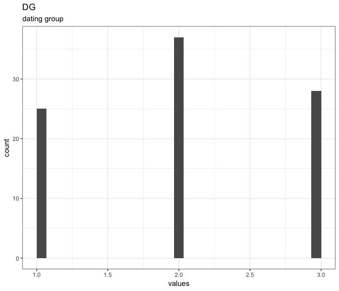

0 missings.

#### Summary statistics

| name | label | data_type | missing | complete | n | mean | sd | p0 | p25 | p50 | p75 | p100 | hist | format.spss |
| --- | --- | --- | --- | --- | --- | --- | --- | --- | --- | --- | --- | --- | --- | --- |
| DG | dating group | numeric | 0 | 90 | 90 | 2.03 | 0.77 | 1 | 1 | 2 | 3 | 3 | ▆▁▁▇▁▁▁▆ | F8.0 |

### sex

sex

#### Distribution

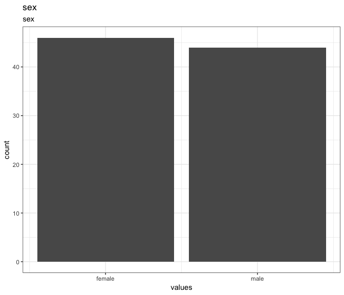

0 missings.

#### Summary statistics

| name | label | data_type | value_labels | missing | complete | n | mean | sd | p0 | p25 | p50 | p75 | p100 | hist | format.spss | display_width |
| --- | --- | --- | --- | --- | --- | --- | --- | --- | --- | --- | --- | --- | --- | --- | --- | --- |
| sex | sex | numeric | 1. female, 2. male | 0 | 90 | 90 | 1.49 | 0.5 | 1 | 1 | 1 | 2 | 2 | ▇▁▁▁▁▁▁▇ | F1.0 | 5 |

#### Value labels

- **female**: *1*
- **male**: *2*

### relStat

relationship status

#### Distribution

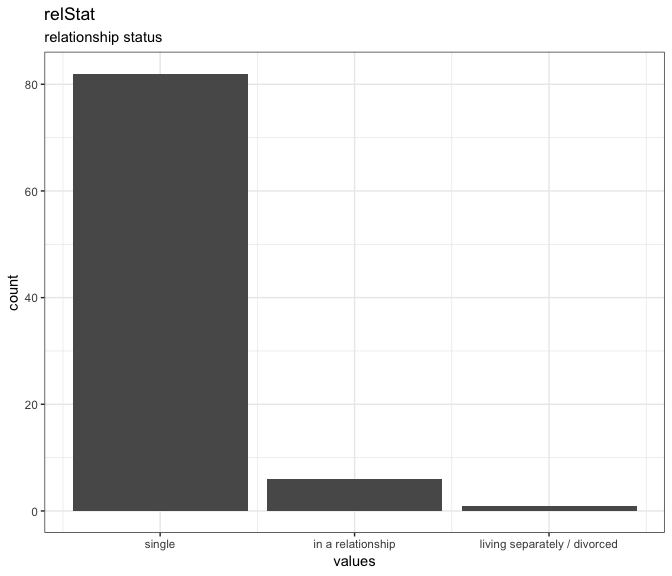

1 missings.

#### Summary statistics

| name | label | data_type | value_labels | missing | complete | n | mean | sd | p0 | p25 | p50 | p75 | p100 | hist | format.spss | display_width |
| --- | --- | --- | --- | --- | --- | --- | --- | --- | --- | --- | --- | --- | --- | --- | --- | --- |
| relStat | relationship status | numeric | 1. single, 2. in a relationship, 3. living separately / divorced | 1 | 89 | 90 | 1.09 | 0.32 | 1 | 1 | 1 | 1 | 3 | ▇▁▁▁▁▁▁▁ | F8.0 | 10 |

#### Value labels

- **single**: *1*
- **in a relationship**: *2*
- **living separately / divorced**: *3*

### education

highest educational attainment

#### Distribution

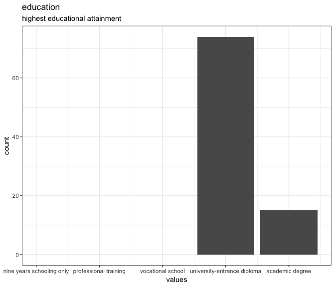

1 missings.

#### Summary statistics

| name | label | data_type | value_labels | missing | complete | n | mean | sd | p0 | p25 | p50 | p75 | p100 | hist | format.spss | display_width |
| --- | --- | --- | --- | --- | --- | --- | --- | --- | --- | --- | --- | --- | --- | --- | --- | --- |
| education | highest educational attainment | numeric | 1. nine years schooling only, 2. professional training, 3. vocational school, 4. university-entrance diploma, 5. academic degree | 1 | 89 | 90 | 4.17 | 0.38 | 4 | 4 | 4 | 4 | 5 | ▇▁▁▁▁▁▁▂ | F1.0 | 5 |

#### Value labels

- **nine years schooling only**: *1*
- **professional training**: *2*
- **vocational school**: *3*
- **university-entrance diploma**: *4*
- **academic degree**: *5*

### NPI_avg

narcissistic personality inventory - average

#### Distribution

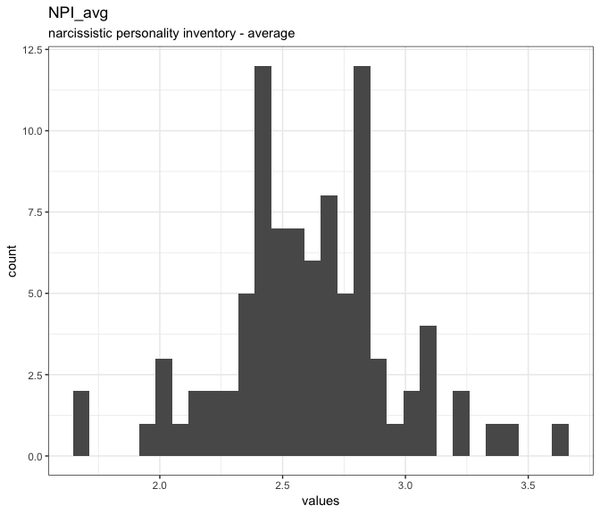

0 missings.

#### Summary statistics

| name | label | data_type | missing | complete | n | mean | sd | p0 | p25 | p50 | p75 | p100 | hist | format.spss | display_width |
| --- | --- | --- | --- | --- | --- | --- | --- | --- | --- | --- | --- | --- | --- | --- | --- |
| NPI_avg | narcissistic personality inventory - average | numeric | 0 | 90 | 90 | 2.61 | 0.35 | 1.7 | 2.42 | 2.6 | 2.82 | 3.65 | ▁▂▃▇▆▂▁▁ | F8.2 | 10 |

## Missingness report

Among those who finished the survey. Only variables that have missings are shown.

| description | relStat | education | var_miss | n_miss |
| --- | --- | --- | --- | --- |
| Missings in 0 variables | 1 | 1 | 0 | 88 |
| Missings per variable | 1 | 1 | 2 | 2 |
| Missings in 1 variables | 1 | 0 | 1 | 1 |
| Missings in 1 variables | 0 | 1 | 1 | 1 |

### Codebook table

| name | label | data_type | value_labels | missing | complete | n | mean | sd | p0 | p25 | p50 | p75 | p100 | hist | format.spss | display_width |
| --- | --- | --- | --- | --- | --- | --- | --- | --- | --- | --- | --- | --- | --- | --- | --- | --- |
| DG | dating group | numeric | NA | 0 | 90 | 90 | 2.03 | 0.77 | 1 | 1 | 2 | 3 | 3 | ▆▁▁▇▁▁▁▆ | F8.0 | NA |
| sex | sex | numeric | 1. female, 2. male | 0 | 90 | 90 | 1.49 | 0.5 | 1 | 1 | 1 | 2 | 2 | ▇▁▁▁▁▁▁▇ | F1.0 | 5 |
| relStat | relationship status | numeric | 1. single, 2. in a relationship, 3. living separately / divorced | 1 | 89 | 90 | 1.09 | 0.32 | 1 | 1 | 1 | 1 | 3 | ▇▁▁▁▁▁▁▁ | F8.0 | 10 |
| education | highest educational attainment | numeric | 1. nine years schooling only, 2. professional training, 3. vocational school, 4. university-entrance diploma, 5. academic degree | 1 | 89 | 90 | 4.17 | 0.38 | 4 | 4 | 4 | 4 | 5 | ▇▁▁▁▁▁▁▂ | F1.0 | 5 |
| NPI_avg | narcissistic personality inventory - average | numeric | NA | 0 | 90 | 90 | 2.61 | 0.35 | 1.7 | 2.42 | 2.6 | 2.82 | 3.65 | ▁▂▃▇▆▂▁▁ | F8.2 | 10 |